# Finalreport_timeseries

7110021065 吳憲中

2022-06-16

# This analysis is base on data from 2303-聯電

```r
load("C:/Users/stran/OneDrive/桌面/時間序列分析/期末報告/2303.rda")
data <- na.omit(data)
row.names(data) <- data$date
data1 <- data
data1$date <- NULL
data2 <- as.data.frame(t(data1[10,]))
#計算stock price
data2$stock_price <- data2$`2020-04-15`
#計算return
return <- as.data.frame(diff(log(data2$stock_price))*100)
row <- c(0)
return <- rbind(row,return)
data2 <- cbind(data2,return)
colnames(data2) <- c("2020-03-23","stock_price","return")
#計算CR
CR <- list()
cr <- 0
for(i in 1:nrow(data2)){
  cr <- cr + data2$return[i]
  CR[i] <- cr
}
CR <- as.data.frame(CR)
CR <- as.data.frame(t(CR))
colnames(CR) <- c("CR")
data2 <- cbind(data2,CR)
#daily price
open <- data$m_090030
close <- data$m_133000
price_daily <- close
#計算daily return
return_daily <- diff(log(close))*100
return_daily <- as.data.frame(return_daily)
#計算return whole
data3 <- data1
for(i in 1:nrow(data1)){
  data3[i,1] <- 0
  for(j in 2:ncol(data1)){
    data3[i,j] <- data1[i,j] - data1[i,j-1]
  }
}
#計算CR whole
data4 <- data1
for(i in 1:nrow(data1)){
  data4[i,1] <- 0
  for(j in 2:ncol(data1)){
    data4[i,j] <- data1[i,j] - data1[i,1]
  }
}
```

## 1. unit Root check ： Phillips and Perron Unit Root Test

### Null Hypothesis : there is no unit root ，$\alpha = 0.05$

#### (a) Please check the existence of a unit root for the time series of minute stock prices, $\lbrace{P_{i,t},T=1,2,\ldots,T-1}\rbrace$ , in a specific trading day i.

```r
sprice.pp <- ur.pp(data2$stock_price, type="Z-alpha", model = "constant", lags = "long")
summary(sprice.pp)
```

```
##
## ##################################
## # Phillips-Perron Unit Root Test #
## ##################################
##
## Test regression with intercept
##
##
## Call:
## lm(formula = y ~ y.l1)
##
## Residuals:
##       Min        1Q    Median        3Q       Max
## -0.065958 -0.003001  0.000237  0.002677  0.078254
##
## Coefficients:
##             Estimate Std. Error t value Pr(>|t|)
## (Intercept)  0.58740    0.26597   2.209   0.0281 *
## y.l1         0.96082    0.01774  54.151   <2e-16 ***
## ---
## Signif. codes:  0 '***' 0.001 '**' 0.01 '*' 0.05 '.' 0.1 ' ' 1
##
## Residual standard error: 0.01207 on 263 degrees of freedom
## Multiple R-squared:  0.9177, Adjusted R-squared:  0.9174
## F-statistic:  2932 on 1 and 263 DF,  p-value: < 2.2e-16
##
##
## Value of test-statistic, type: Z-alpha  is: -12.6109
##
##          aux. Z statistics
## Z-tau-mu            2.4471
```

```r
plot(data2$stock_price)
```

#### With Phillips and Perron test , we have result that p-value nearly equal to zero , hence we reject null hypothesis which means there is unit root for the time series of minute stock prices, $\lbrace{P_{i,t},T=1,2,\ldots,T-1}\rbrace$ .

#### (b) Please check the existence of a unit root for the time series of minute compound returns, $\lbrace{r_{i,t},T=1,2,\ldots,T-1}\rbrace$ , in a specific trading day i.

```r
return.pp <- ur.pp(data2$return, type="Z-alpha", model = "constant", lags = "long")
summary(return.pp)
```

```
##
## ##################################
## # Phillips-Perron Unit Root Test #
## ##################################
##
## Test regression with intercept
##
##
## Call:
## lm(formula = y ~ y.l1)
##
## Residuals:
##      Min       1Q   Median       3Q      Max
## -0.44159 -0.01809  0.00070  0.01691  0.48359
##
## Coefficients:
##               Estimate Std. Error t value Pr(>|t|)
## (Intercept)  0.0001648  0.0049586   0.033    0.974
## y.l1        -0.1055069  0.0666259  -1.584    0.114
##
## Residual standard error: 0.0807 on 263 degrees of freedom
## Multiple R-squared:  0.009445,   Adjusted R-squared:  0.005679
## F-statistic: 2.508 on 1 and 263 DF,  p-value: 0.1145
##
##
## Value of test-statistic, type: Z-alpha  is: -297.9982
##
##          aux. Z statistics
## Z-tau-mu            0.0339
```

```r
plot(data2$return)
```

#### (c) Please check the existence of a unit root for the time series of minute cumulative returns, $\lbrace{CR_{i,t},T=1,2,\ldots,T-1}\rbrace$ , in a specific trading day i.

```r
CR.pp <- ur.pp(data2$CR, type="Z-alpha", model = "constant", lags = "long")
summary(CR.pp)
```

```
##
## ##################################
## # Phillips-Perron Unit Root Test #
## ##################################
##
## Test regression with intercept
##
##
## Call:
## lm(formula = y ~ y.l1)
##
## Residuals:
##      Min       1Q   Median       3Q      Max
## -0.43814 -0.02002  0.00159  0.01797  0.51960
##
## Coefficients:
##             Estimate Std. Error t value Pr(>|t|)
## (Intercept) -0.02489    0.01245  -1.999   0.0466 *
## y.l1         0.96089    0.01772  54.215   <2e-16 ***
## ---
## Signif. codes:  0 '***' 0.001 '**' 0.01 '*' 0.05 '.' 0.1 ' ' 1
##
## Residual standard error: 0.08034 on 263 degrees of freedom
## Multiple R-squared:  0.9179, Adjusted R-squared:  0.9176
## F-statistic:  2939 on 1 and 263 DF,  p-value: < 2.2e-16
##
##
## Value of test-statistic, type: Z-alpha  is: -12.5941
##
##          aux. Z statistics
## Z-tau-mu           -2.2209
```

```r
plot(data2$CR)
```

#### With Phillips and Perron test , we have result that p-value nearly equal to zero , hence we reject null hypothesis which means there is unit root for the time series of minute cumulative returns, $\lbrace{CR_{i,t},T=1,2,\ldots,T-1}\rbrace$ .

#### (d) Please check the existence of a unit root for the time series of daily prices, $\lbrace{P_{i},i=1,2,\ldots,N}\rbrace$ .

```r
price_daily.pp <- ur.pp(price_daily, type="Z-alpha", model = "constant", lags = "long")
summary(price_daily.pp)
```

```
##
## ##################################
## # Phillips-Perron Unit Root Test #
## ##################################
##
## Test regression with intercept
##
##
## Call:
## lm(formula = y ~ y.l1)
##
## Residuals:
##     Min      1Q  Median      3Q     Max
## -4.1637 -0.6602 -0.0917  0.6488  6.0528
##
## Coefficients:
##             Estimate Std. Error t value Pr(>|t|)
## (Intercept) 0.368781   0.166964   2.209   0.0276 *
## y.l1        0.993413   0.003482 285.333   <2e-16 ***
## ---
## Signif. codes:  0 '***' 0.001 '**' 0.01 '*' 0.05 '.' 0.1 ' ' 1
##
## Residual standard error: 1.287 on 506 degrees of freedom
## Multiple R-squared:  0.9938, Adjusted R-squared:  0.9938
## F-statistic: 8.141e+04 on 1 and 506 DF,  p-value: < 2.2e-16
##
##
## Value of test-statistic, type: Z-alpha  is: -3.2141
##
##          aux. Z statistics
## Z-tau-mu            2.2348
```

```r
plot(price_daily)
```

#### With Phillips and Perron test , we have result that p-value nearly equal to zero , hence we reject null hypothesis which means there is unit root for the time series of daily prices, $\lbrace{P_{i},i=1,2,\ldots,N}\rbrace$ .

#### (e) Please check the existence of a unit root for the time series of daily compound returns, $\lbrace{r_{i},i=2,\ldots,N}\rbrace$ .

```r
return_daily.pp <- ur.pp(return_daily$return_daily, type="Z-alpha", model = "constant", lags = "long")
summary(return_daily.pp)
```

```
##
## ##################################
## # Phillips-Perron Unit Root Test #
## ##################################
##
## Test regression with intercept
##
##
## Call:
## lm(formula = y ~ y.l1)
##
## Residuals:
##     Min      1Q  Median      3Q     Max
## -7.7271 -1.6811 -0.0988  1.5049  9.6137
##
## Coefficients:
##             Estimate Std. Error t value Pr(>|t|)
## (Intercept)  0.23745    0.12586   1.887   0.0598 .
## y.l1         0.06578    0.04441   1.481   0.1392
## ---
## Signif. codes:  0 '***' 0.001 '**' 0.01 '*' 0.05 '.' 0.1 ' ' 1
##
## Residual standard error: 2.822 on 505 degrees of freedom
## Multiple R-squared:  0.004326,   Adjusted R-squared:  0.002354
## F-statistic: 2.194 on 1 and 505 DF,  p-value: 0.1392
##
##
## Value of test-statistic, type: Z-alpha  is: -481.0392
##
##          aux. Z statistics
## Z-tau-mu            1.8886
```

```r
plot(return_daily$return_daily)
```

#### With Phillips and Perron test , we have result that p-value = 0.1392 , hence we do not reject null hypothesis which means there is no unit root for the time series of daily compound returns, $\lbrace{r_{i},i=2,\ldots,N}\rbrace$ .

#### By the result of above , I make a conclusion that the data seems like to have higher volatility tend to have unitroots .Theoretically , data has unitroot implies randomness .

## 2. Mean change check : Chow test

### Null Hypothesis : there is no mean change or structure change ，$\alpha = 0.05$

#### (a) Please check the existence of mean changes for the time series of minute stock prices , $\lbrace{P_{i,t},T=1,2,\ldots,T-1}\rbrace$ , in a specific trading day i.

```r
sctest(data2$stock_price ~1, type = "Chow", point = 100)
```

```
##
##  Chow test
##
## data:  data2$stock_price ~ 1
## F = 33.316, p-value = 2.192e-08
```

```r
plot(data2$stock_price)
```

#### With Chow test , we have result that p-value nearly equal to zero , hence we reject null hypothesis which means there is mean change or structure change for the time series of minute stock prices , $\lbrace{P_{i,t},T=1,2,\ldots,T-1}\rbrace$ .

#### (b) Please check the existence of mean changes for the time series of minute compound returns, $\lbrace{r_{i,t},T=2,\ldots,T-1}\rbrace$ , in a specific trading day i.

```r
sctest(data2$return ~1, type = "Chow", point = 100)
```

```
##
##  Chow test
##
## data:  data2$return ~ 1
## F = 1.1875, p-value = 0.2768
```

```r
plot(data2$return)
```

#### (c) Please check the existence of mean changes for the time series of minute cumulative returns, $\lbrace{CR_{i,t},T=2,\ldots,T-1}\rbrace$ , in a specific trading day i.

```r
sctest(data2$CR ~1, type = "Chow", point = 100)
```

```
##
##  Chow test
##
## data:  data2$CR ~ 1
## F = 33.349, p-value = 2.159e-08
```

```r
plot(data2$CR)
```

#### With Chow test , we have result that p-value nearly equal to zero , hence we reject null hypothesis which means there is mean change or structure change for the time series of minute cumulative returns, $\lbrace{CR_{i,t},T=2,\ldots,T-1}\rbrace$ .

#### (d) Please check the existence of mean changes for the time series of daily prices, $\lbrace{P_{i},i=1,2,\ldots,N}\rbrace$ .

```r
sctest(price_daily ~1, type = "Chow", point = 100)
```

```
##
##  Chow test
##
## data:  price_daily ~ 1
## F = 1013.7, p-value < 2.2e-16
```

```r
plot(price_daily)
```

#### With Chow test , we have result that p-value nearly equal to zero , hence we reject null hypothesis which means there is mean change or structure change for the time series of daily prices, $\lbrace{P_{i},i=1,2,\ldots,N}\rbrace$ .

#### (e) Please check the existence of mean changes for the time series of daily compound returns , $\lbrace{r_{i},i=2,\ldots,N}\rbrace$ .

```r
sctest(return_daily$return_daily ~1, type = "Chow", point = 100)
```

```
##
##  Chow test
##
## data:  return_daily$return_daily ~ 1
## F = 1.3069, p-value = 0.2535
```

```r
plot(return_daily$return_daily)
```

#### By the result of above , We can see plots, data which has no mean change or structure change are relatively stable .I make a conclusion that the data seems like to have mean change or structure change with higher volatility .

## 3. Stationarity check :

### Null Hypothesis : data is stationary ，$\alpha = 0.05$

#### (a) Please check the stationarity for the time series of minute stock prices , $\lbrace{P_{i,t},T=1,2,\ldots,T-1}\rbrace$ , in a specific trading day i.

```r
kpss.test(data2$stock_price, null = "Trend")
```

```
##
##  KPSS Test for Trend Stationarity
##
## data:  data2$stock_price
## KPSS Trend = 0.38834, Truncation lag parameter = 5, p-value = 0.01
```

```r
plot(data2$stock_price)
```

#### With KPSS test , we have result that p-value smaller than crytical number , hence we reject null hypothesis which means its not stationary for the time series of minute stock prices , $\lbrace{P_{i,t},T=1,2,\ldots,T-1}\rbrace$ .

#### (b) Please check the stationarity for the time series of minute compound returns , $\lbrace{r_{i,t},T=2,\ldots,T-1}\rbrace$ , in a specific trading day i.

```r
kpss.test(data2$return, null = "Trend")
```

```
##
##  KPSS Test for Trend Stationarity
##
## data:  data2$return
## KPSS Trend = 0.072086, Truncation lag parameter = 5, p-value = 0.1
```

```r
plot(data2$return)
```

#### (c) Please check the stationarity for the time series of minute cumulative returns, $\lbrace{CR_{i,t},T=2,\ldots,T-1}\rbrace$ , in a specific trading day i.

```r
kpss.test(data2$CR, null = "Trend")
```

```
##
##  KPSS Test for Trend Stationarity
##
## data:  data2$CR
## KPSS Trend = 0.38707, Truncation lag parameter = 5, p-value = 0.01
```

```r
plot(data2$CR)
```

#### With KPSS test , we have result that p-value smaller than crytical number , hence we reject null hypothesis which means its not stationary for the time series of minute cumulative returns, $\lbrace{CR_{i,t},T=2,\ldots,T-1}\rbrace$ .

#### (d) Please check the stationarity for the time series of daily prices, $\lbrace{P_{i},i=1,2,\ldots,N}\rbrace$ .

```r
kpss.test(price_daily, null = "Trend")
```

```
##
##  KPSS Test for Trend Stationarity
##
## data:  price_daily
## KPSS Trend = 1.4001, Truncation lag parameter = 6, p-value = 0.01
```

```r
plot(price_daily)
```

#### With KPSS test , we have result that p-value smaller than crytical number , hence we reject null hypothesis which means its not stationary for the time series of daily prices, $\lbrace{P_{i},i=1,2,\ldots,N}\rbrace$ .

#### (e) Please check the stationarity for the time series of daily compound returns , $\lbrace{r_{i},i=2,\ldots,N}\rbrace$ .

```r
kpss.test(return_daily$return_daily, null = "Trend")
```

```
##
##  KPSS Test for Trend Stationarity
##
## data:  return_daily$return_daily
## KPSS Trend = 0.028825, Truncation lag parameter = 6, p-value = 0.1
```

```r
plot(return_daily$return_daily)
```

#### By the result of above , We can see plots, data which is stationary are relatively stable .I make a conclusion that the data seems like higher volatility lead non-stationary .

## 4. Statistical inferences :

#### (a)Is it appropriate to test $H_{0} : E(P_{i,t}) = P_{0}$ with $\lbrace{P_{i,t},T=2,\ldots,T-1}\rbrace ?$ If yes, how do you do the inference $?$

```r
plot(data2$stock_price)
```

#### I think it can’t be test , becasue the data is not stationary which means with different period of data we select there can be different $P_{0}$ . And becuase of the volatility , it’s hard to define $P_{0}$ . Even we choose one $P_{0}$ , it might lack of representative for whole data.

#### (b)Is it appropriate to test $H_{0} : E(r_{i,t}) = 0$ with $\lbrace{r_{i,t},T=2,\ldots,T-1}\rbrace ?$ If yes, how do you do the inference $?$

```r
plot(data2$return)
```

#### With intuition by just looking the plot , we can easily say that it’s able to test . Since return are sationary , and it seems has the mean to converge . Also the data of return is not highly volatility , 0 may represent all observation in data .

#### (c)Is it appropriate to test $H_{0} : E(CR_{i,t}) = 0$ with $\lbrace{CR_{i,t},T=2,\ldots,T-1}\rbrace ?$ If yes, how do you do the inference $?$

```r
plot(data2$CR)
```

#### Same , because of the data is non-stationary , as time goes on ,data will deviate because of its autocorrelation impact,so we can’t test it .

#### (d)Is it appropriate to test $H_{0} : E(P_{i}) = P_{0}$ with $\lbrace{P_{i},i=1,2,\ldots,N}\rbrace ?$ If yes, how do you do the inference $?$

```r
plot(price_daily)
```

#### Same result with 2-(a) , it’s hard to define $P_{0}$ . Even we choose one $P_{0}$ , it might lack of representative for whole data. So I think it can’t be tested . The volatility of data might makes $E(P_{i})$ not representive whole data . For example , at index = 400 , we can see that trend before that time were totally different from trend after it . Since the pirce is unpredictable ,we can say what trend will be with 100% faith .

#### (e)Is it appropriate to test $H_{0} : E(r_{i}) = 0$ with $\lbrace{r_{i},i=2,\ldots,N}\rbrace ?$ If yes, how do you do the inference $?$

```r
plot(return_daily$return_daily)
```

#### Although the data is vary , but we still can see that its average is laying on one identical number , maybe its mean .Furthermore , the data is stationary ,so I think it can be tested .

## 5. Build-up time series models :

#### (a)Is it appropriate to build up an ARMA (p, q) to represent the time dependence of the stochastic process with $\lbrace{P_{i,t},T=2,\ldots,T-1}\rbrace ?$ If yes, what is your suggested model $?$

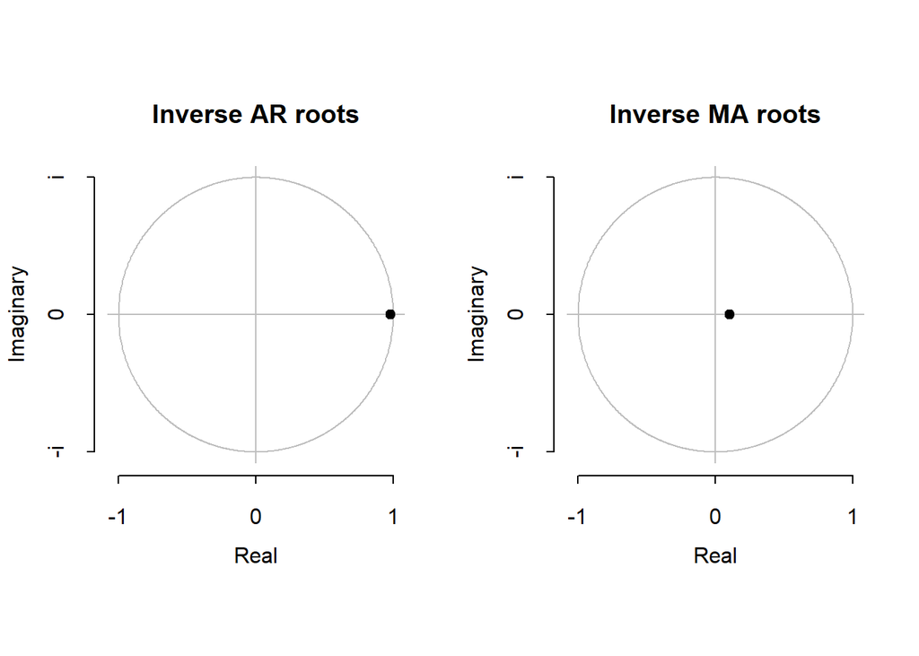

```r
ar1 <- arima(data2$stock_price, order=c(1,0,1))
plot(ar1)
```

#### (b)Is it appropriate to build up an ARMA (p, q) to represent the time dependence of the stochastic process with $\lbrace{r_{i,t},T=2,\ldots,T-1}\rbrace ?$ If yes, what is your suggested model $?$

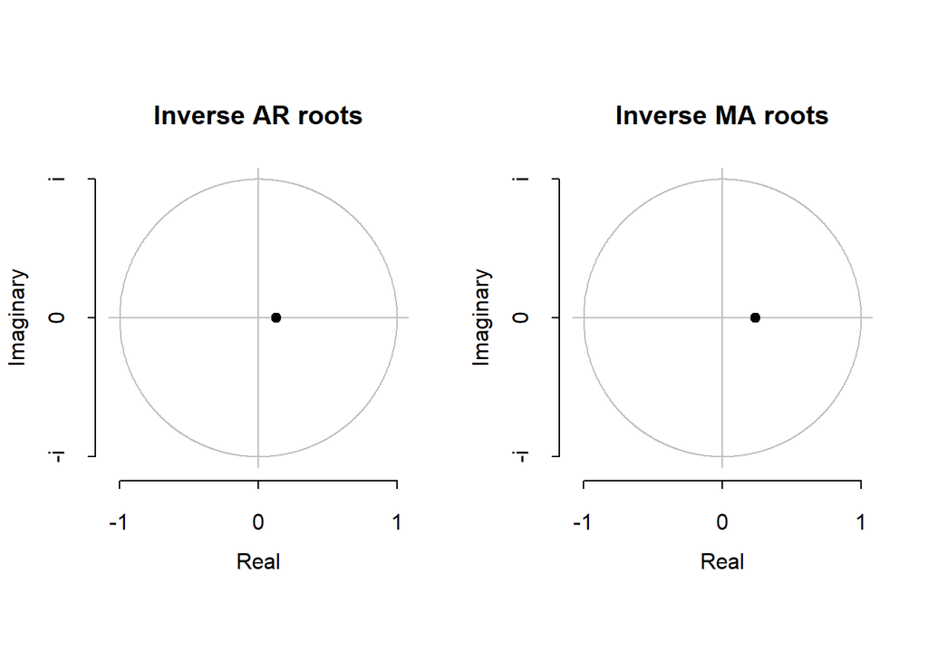

```r
ar2 <- arima(data2$return, order=c(1,0,1))
plot(ar2)
```

#### (c)Is it appropriate to build up an ARMA (p, q) to represent the time dependence of the stochastic process with $\lbrace{CR_{i,t},T=2,\ldots,T-1}\rbrace ?$ If yes, what is your suggested model $?$

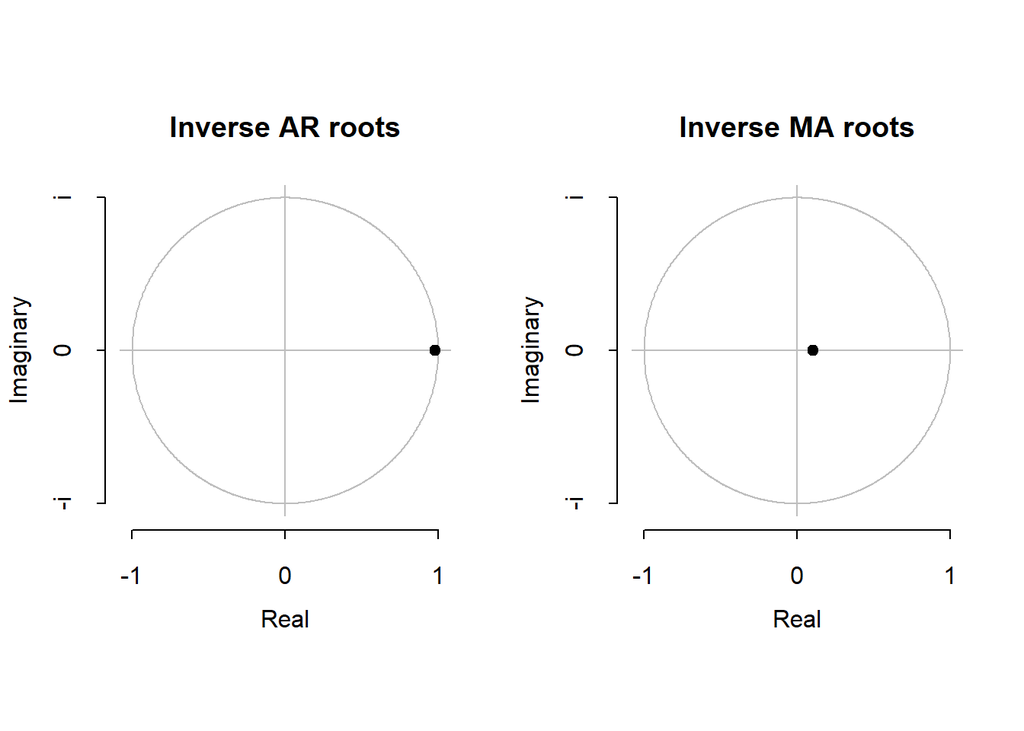

```r
ar3 <- arima(data2$CR, order=c(1,0,1))
plot(ar3)
```

#### (d)Is it appropriate to build up an ARMA (p, q) to represent the time dependence of the stochastic process with $\lbrace{P_{i},i=1,2,\ldots,N}\rbrace ?$ If yes, what is your suggested model $?$

```r
ar4 <- arima(price_daily, order=c(1,0,1))
```

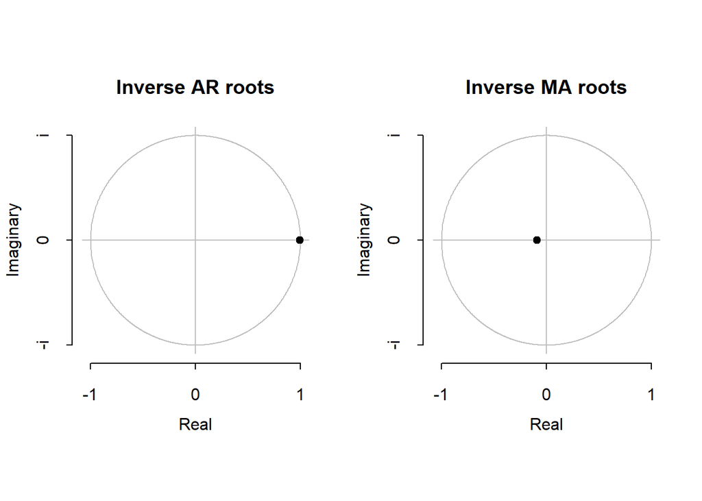

```r
plot(ar4)
```

#### (e)Is it appropriate to build up an ARMA (p, q) to represent the time dependence of the stochastic process with $\lbrace{r_{i},i=2,\ldots,N}\rbrace ?$ If yes, what is your suggested model $?$

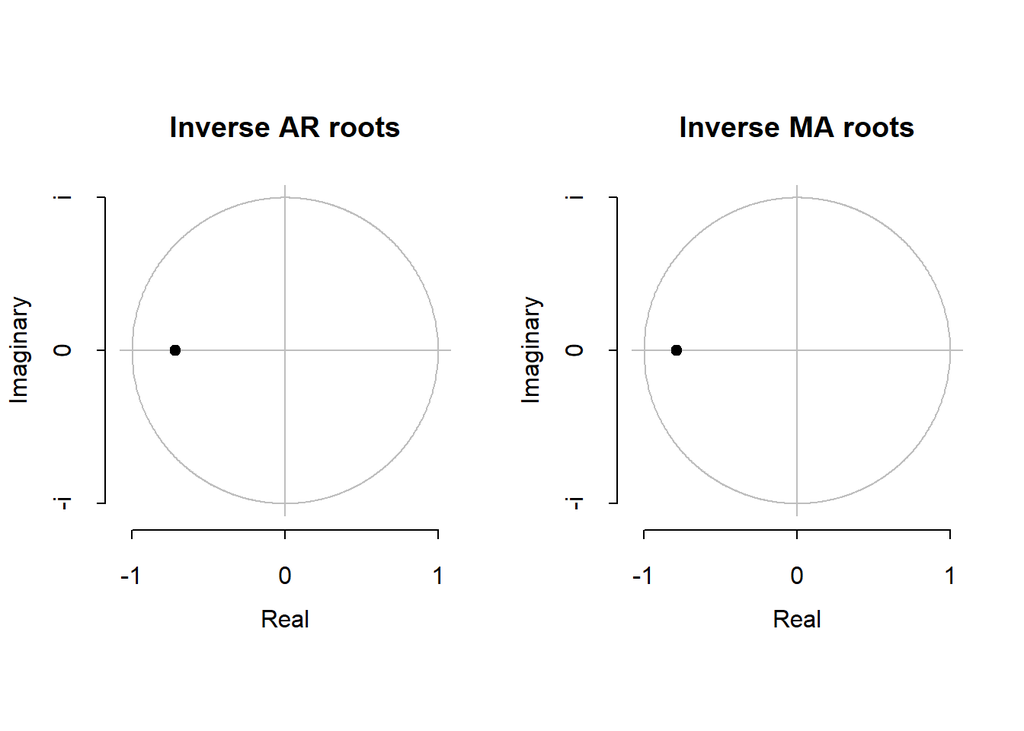

```r
ar5 <- arima(return_daily$return_daily, order=c(1,0,1))
plot(ar5)
```

#### All of data can be build up an $ARMA(p,q)$ to represent the time dependence of the stochastic process ,because all this timseries data are autocorrelative .Also with AR we find out that only minute stock prices , minute cumulative returns and daily prices have unitRoot .Same result by early work .

## 6. Forecasts evaluations :

#### Yes ,we can . Since the data is stationary , we can find the pattern of forecasts return ,makes the future return might be predictable .

```r
od <- options(digits = 5) # avoid too much spurious accuracy
predict(arima(lh, order = c(3,0,0)), n.ahead = 12)
```

```
## $pred
## Time Series:
## Start = 49
## End = 60
## Frequency = 1
##  [1] 2.4602 2.2708 2.1986 2.2607 2.3470 2.4145 2.4389 2.4315 2.4102 2.3917
## [11] 2.3827 2.3827
##
## $se
## Time Series:
## Start = 49
## End = 60
## Frequency = 1
##  [1] 0.42268 0.50293 0.52452 0.52472 0.53055 0.53692 0.53880 0.53884 0.53910
## [10] 0.53952 0.53970 0.53971
```

```r
(fit <- arima(return_daily, order = c(0,1,1),
              seasonal = list(order = c(0,1,1))))
```

```
##
## Call:
## arima(x = return_daily, order = c(0, 1, 1), seasonal = list(order = c(0, 1,
##     1)))
##
## Coefficients:
##         ma1   sma1
##       -1.00  -1.00
## s.e.   0.01   0.01
##
## sigma^2 estimated as 7.89:  log likelihood = -1251.9,  aic = 2507.7
```

```r
predict(fit, n.ahead = 6)
```

```
## $pred
## Time Series:
## Start = 509
## End = 514
## Frequency = 1
## [1] -0.27262 -0.27469 -0.27677 -0.27884 -0.28092 -0.28299
##
## $se
## Time Series:
## Start = 509
## End = 514
## Frequency = 1
## [1] 2.8203 2.8204 2.8205 2.8205 2.8206 2.8207
```

```r
options(od)
```

## 7. Reconstruction for Functional Data :

#### (a) Reconstruct the functional data with FPCA with

$$\lbrace{r_{i,t},i=1,\ldots,N,T=2,\ldots,T}\rbrace$$

```r
nbasis = 6
basisobj <- create.monomial.basis(c(-1,1), nbasis)
```

```r
T <- ncol(data3)
argvals = seq(0,1,len=266)
Ys = smooth.basis(argvals=argvals, y=t(data3), fdParobj=basisobj,
                  returnMatrix=TRUE)
Xfd = Ys$fd
coeff <- Xfd$coefs
Rec_y <- t(eval.fd(argvals, Xfd))
```

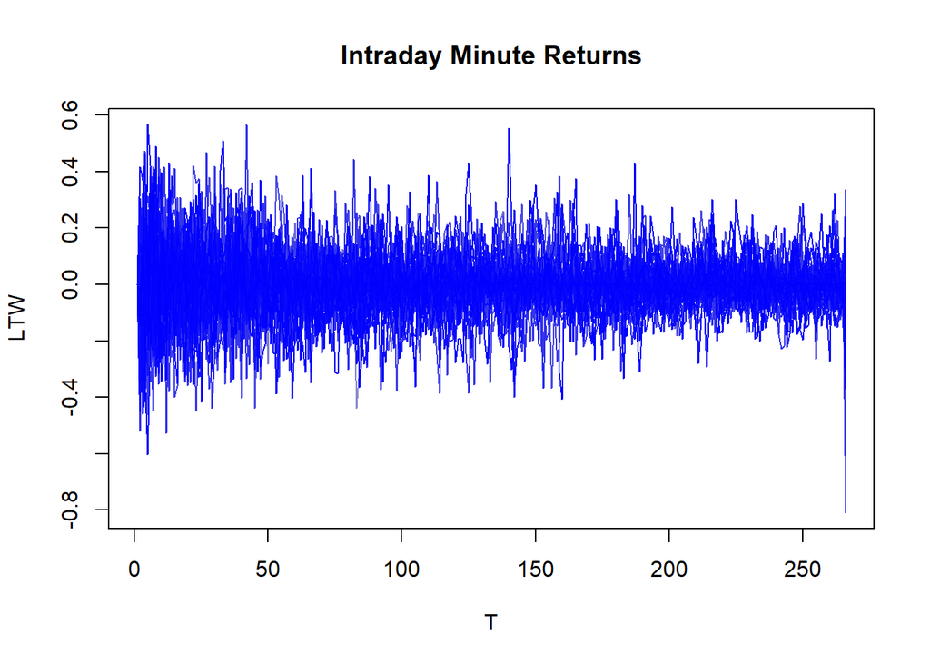

```r
N <- NROW(data3)
T <- NCOL(data3)

colfuncf <- colorRampPalette(c("grey", "blue"))
color.setf <- colfuncf(T)
par(mfrow=c(1,1))
plot(seq(1,T,1),data3[1,],ylim=range(data3),type="l",
     main="Intraday Minute Returns",ylab="LTW",xlab="T", col=color.setf[1])
for (i in 2:N){
  lines(seq(1,T,1),data3[i,], col=color.setf[i])
}
```

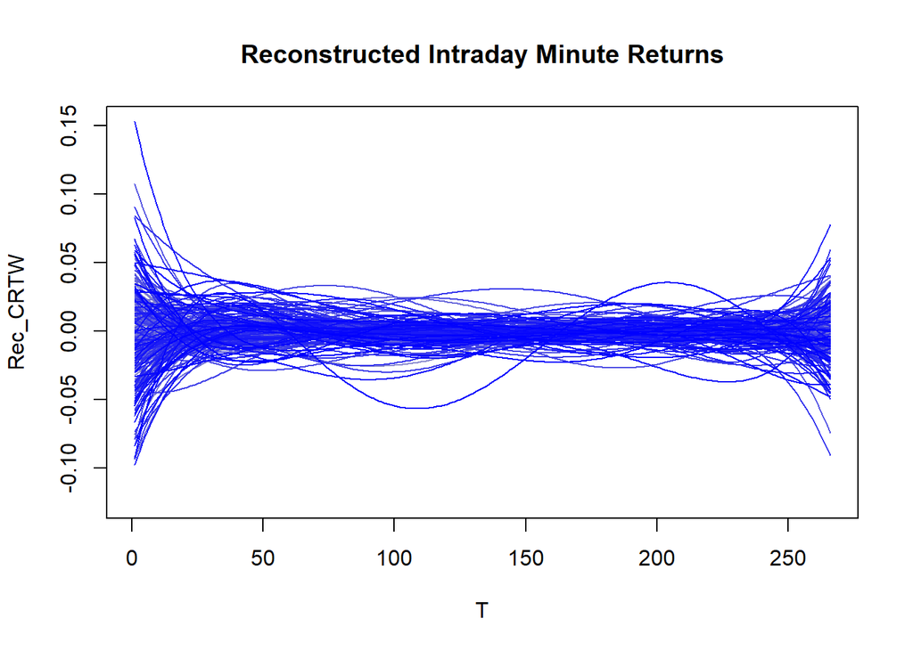

```r
par(mfrow=c(1,1))
plot(seq(1,T,1),Rec_y[1,],ylim=range(Rec_y),type="l",
     main="Reconstructed Intraday Minute Returns",ylab="Rec_CRTW",xlab="T", col=color.setf[1])
for (i in 2:N){
  lines(seq(1,T,1),Rec_y[i,], col=color.setf[i])
}
```

#### (b) Reconstruct the functional data with FPCA with

#### $$\lbrace{CR_{i,t},i=1,\ldots,N , T=2,\ldots,T}\rbrace$$

```r
nbasis = 6
basisobj <- create.monomial.basis(c(-1,1), nbasis)
```

```r
T <- ncol(data4)
argvals = seq(0,1,len=266)
Ys = smooth.basis(argvals=argvals, y=t(data4), fdParobj=basisobj,
                  returnMatrix=TRUE)
Xfd = Ys$fd
coeff <- Xfd$coefs
Rec_y <- t(eval.fd(argvals, Xfd))
```

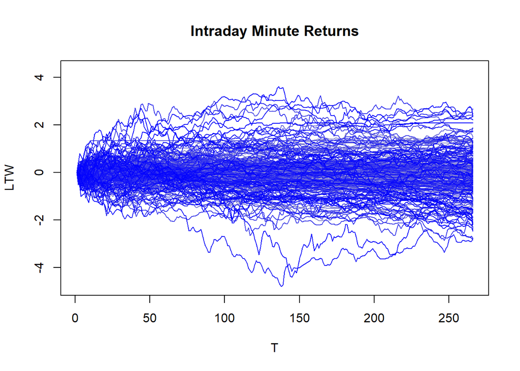

```r
N <- NROW(data4)
T <- NCOL(data4)

colfuncf <- colorRampPalette(c("grey", "blue"))
color.setf <- colfuncf(T)
par(mfrow=c(1,1))
plot(seq(1,T,1),data4[1,],ylim=range(data4),type="l",
     main="Intraday Minute Returns",ylab="LTW",xlab="T", col=color.setf[1])
for (i in 2:N){
  lines(seq(1,T,1),data4[i,], col=color.setf[i])
}
```

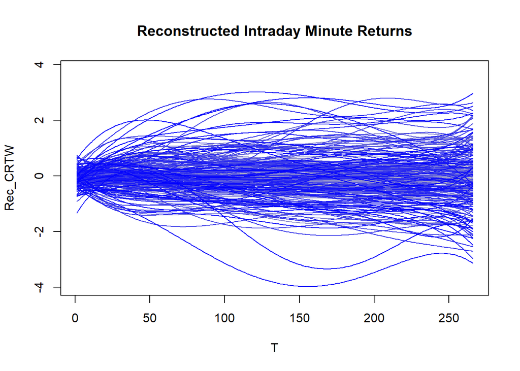

```r
par(mfrow=c(1,1))
plot(seq(1,T,1),Rec_y[1,],ylim=range(Rec_y),type="l",
     main="Reconstructed Intraday Minute Returns",ylab="Rec_CRTW",xlab="T", col=color.setf[1])
for (i in 2:N){
  lines(seq(1,T,1),Rec_y[i,], col=color.setf[i])
}
```